# KDM2B-mediated PRC1 recruitment to chromatin: RNA-seq & ChIP-seq data analysis

Alessandro Digilio

2024-05-27

# **RNA-seq analysis**

In this report it is shown how to process RNA-Seq and ChIP-Seq data from raw FASTQ files. The data derive from GEO data bank (GEO Series: GSE190807) that consists in three biological replicates each for wt NSCand km2b mutated NSC cells from *Mus musculus*.

# Load the data

Use `fasterq` to download the FASTQ files associated with the SRA runs IDs. To do this create a script (load.data.sh) with `vim` (make it executable with `chmod u+x`).

```bash
cd ..
head load_data.sh
```

```
## fasterq-dump SRR17223720
## fasterq-dump SRR17223721
## fasterq-dump SRR17223722
## fasterq-dump SRR17223723
## fasterq-dump SRR17223724
## fasterq-dump SRR17223725
```

Change the names of each file (with `mv`) from a new script (rename.sh)

```bash
cd ..
head rename.sh
```

```
## mv SRR17223720.fastq SRR17223720_NPC_wt_rep1.fastq
## mv SRR17223721.fastq SRR17223721_NPC_wt_rep2.fastq
## mv SRR17223722.fastq SRR17223722_NPC_wt_rep3.fastq
## mv SRR17223723.fastq SRR17223723_NPC_mutkdm2b_rep1.fastq
## mv SRR17223724.fastq SRR17223724_NPC_mutkdm2b_rep2.fastq
## mv SRR17223725.fastq SRR17223725_NPC_mutkdm2b_rep3.fastq
```

# FASTQ quality score

Use `fastqc` for overall reads quality check: `fastqc *fastq`

Use `multiqc . --ignore ChIP-Seq` in the project_track1 dir to summarize all the fastqc results of rnaseq data in a single html report

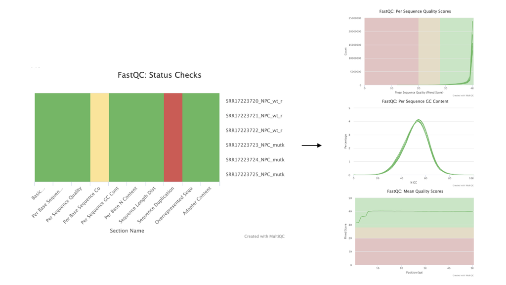

# Mapping

You have to build the index for the genome/transcriptome you want to map reads on (the index-building program is included in the software package of the read mapper).

The index starts from the (multi)FASTA file of the genome, split into chromosomes or, for transcriptomes, the sequences of transcripts.

We want the mm9 version of the mus musculus genome (in FASTA format) for preparing our index.

```bash
cd ..
head ref_chroms.sh
```

```
## wget https://hgdownload.soe.ucsc.edu/goldenPath/mm9/bigZips/chromFa.tar.gz
## tar -xvf chromFa.tar.gz
## rm *_random.fa
## rm *M.fa
```

After removing non-canonical chromosomes:

```bash
cd ../Index/mm9/chroms
ls
```

```
## chr10.fa
## chr11.fa
## chr12.fa
## chr13.fa
## chr14.fa
## chr15.fa
## chr16.fa
## chr17.fa
## chr18.fa
## chr19.fa
## chr1.fa
## chr2.fa
## chr3.fa
## chr4.fa
## chr5.fa
## chr6.fa
## chr7.fa
## chr8.fa
## chr9.fa
## chrX.fa
## chrY.fa
```

Index for RSEM: download it with `wget,` unzip it with `gunzip` and use the `rsem-prepare-reference` command to prepare the index of the transcriptome.

```bash
cd ..
head ref_genes.sh
```

```
## wget https://hgdownload.soe.ucsc.edu/goldenPath/mm9/bigZips/genes/mm9.refGene.gtf.gz
## gunzip mm9.refGene.gtf.gz
## nohup rsem-prepare-reference --gtf /home/MBB24_adig/project_track1/Index/mm9.refGene.gtf --star -p 2 /home/MBB24_adig/project_track1/Index/mm9/chroms/ mm9_refseq &
```

# Quantification (read counting)

After mapping reads on the genome/transcriptome, we want to count how many belong to each gene. We use the RSEM mapping tool.

```bash
cd ..
head mapping.sh
```

```
## rsem-calculate-expression -p 4 --star SRR17223720_NPC_wt_rep1.fastq /home/MBB24_adig/project_track1/Index/mm9_refseq NPC_wt_rep1
## rsem-calculate-expression -p 4 --star SRR17223721_NPC_wt_rep2.fastq /home/MBB24_adig/project_track1/Index/mm9_refseq NPC_wt_rep2
## rsem-calculate-expression -p 4 --star SRR17223722_NPC_wt_rep3.fastq /home/MBB24_adig/project_track1/Index/mm9_refseq NPC_wt_rep3
## rsem-calculate-expression -p 4 --star SRR17223723_NPC_mutkdm2b_rep1.fastq /home/MBB24_adig/project_track1/Index/mm9_refseq NPC_mutkdm2b_rep1
## rsem-calculate-expression -p 4 --star SRR17223724_NPC_mutkdm2b_rep2.fastq /home/MBB24_adig/project_track1/Index/mm9_refseq NPC_mutkdm2b_rep2
## rsem-calculate-expression -p 4 --star SRR17223725_NPC_mutkdm2b_rep3.fastq /home/MBB24_adig/project_track1/Index/mm9_refseq NPC_mutkdm2b_rep3
```

# Post-mapping quality checks

Make RSEM plot some plots with `rsem-plot-model` command that can help us evaluate the quality of the mapping of our samples from a new script (post_mapping.sh)

```bash
cd ..
head post_mapping.sh
```

```
## rsem-plot-model NPC_wt_rep1 NPC_wt_rep1.pdf
## rsem-plot-model NPC_wt_rep2 NPC_wt_rep2.pdf
## rsem-plot-model NPC_wt_rep3 NPC_wt_rep3.pdf
## rsem-plot-model NPC_mutkdm2b_rep1 NPC_mutkdm2b_rep1.pdf
## rsem-plot-model NPC_mutkdm2b_rep2 NPC_mutkdm2b_rep2.pdf
## rsem-plot-model NPC_mutkdm2b_rep3 NPC_mutkdm2b_rep3.pdf
```

```bash
cd ..
head samtools.sh
```

```
## samtools stats NPC_wt_rep1.transcript.bam > NPC_wt_rep1.transcript.bam.stats
## samtools stats NPC_wt_rep2.transcript.bam > NPC_wt_rep2.transcript.bam.stats
## samtools stats NPC_wt_rep3.transcript.bam > NPC_wt_rep3.transcript.bam.stats
## samtools stats NPC_mutkdm2b_rep1.transcript.bam > NPC_mutkdm2b_rep1.transcript.bam.stats
## samtools stats NPC_mutkdm2b_rep2.transcript.bam > NPC_mutkdm2b_rep2.transcript.bam.stats
## samtools stats NPC_mutkdm2b_rep3.transcript.bam > NPC_mutkdm2b_rep3.transcript.bam.stats
```

```bash
cd ..
head plot_bamstats.sh
```

```
## plot-bamstats -p NPC_wt_rep1.transcript_stats/ NPC_wt_rep1.transcript.bam.stats
## plot-bamstats -p NPC_wt_rep2.transcript_stats/ NPC_wt_rep2.transcript.bam.stats
## plot-bamstats -p NPC_wt_rep3.transcript_stats/ NPC_wt_rep3.transcript.bam.stats
## plot-bamstats -p NPC_mutkdm2b_rep1.transcript_stats/ NPC_mutkdm2b_rep1.transcript.bam.stats
## plot-bamstats -p NPC_mutkdm2b_rep2.transcript_stats/ NPC_mutkdm2b_rep2.transcript.bam.stats
## plot-bamstats -p NPC_mutkdm2b_rep3.transcript_stats/ NPC_mutkdm2b_rep3.transcript.bam.stats
```

Check what’s inside the folders

```bash
cd ../NPC_wt_rep1.stat
ls -l
```

```
## total 1412
## -rw-r--r-- 1 MBB24_adig mbb2024     476 May 28 21:12 NPC_wt_rep1.cnt
## -rw-r--r-- 1 MBB24_adig mbb2024  116440 May 28 21:31 NPC_wt_rep1.model
## -rw-r--r-- 1 MBB24_adig mbb2024 1321515 May 28 21:31 NPC_wt_rep1.theta
```

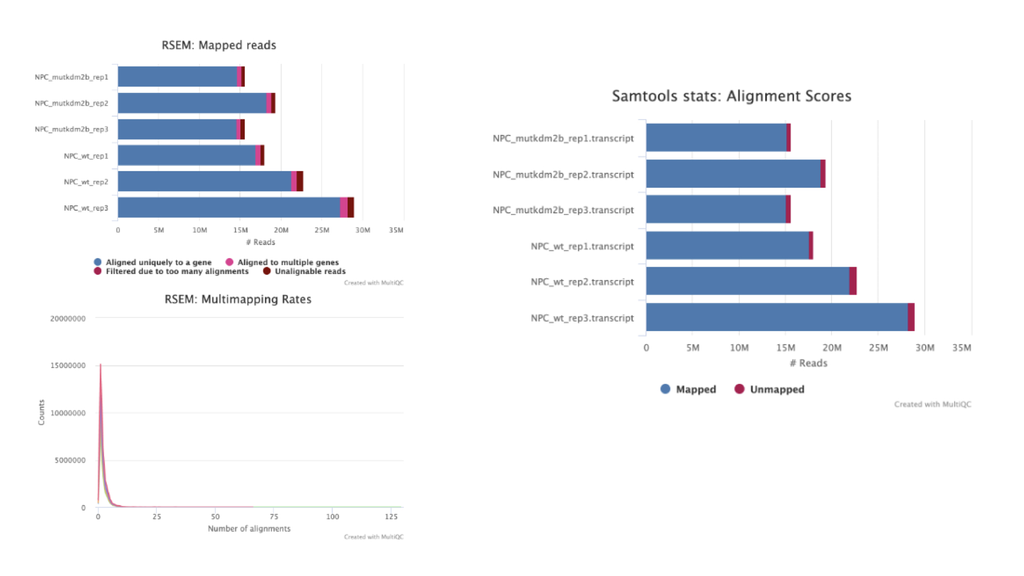

# **Differential Gene Expression Analysis**

In DGE analysis the aim is to identify genes that behave differently between two or more conditions. The analysis is done on R studio with the `edgeR` package.

Load libraries

```r
# load packages
library(edgeR)
```

```r
library(ggplot2)
library(vidger)
```

Import the .genes.results files. The expected counts of RSEM are on the 4th column of each counts table file

```r
# import samples (genes.results files)
NPC_wt_1 <- read.table("~/project_track1/NPC_wt_rep1.genes.results", header = TRUE, sep = "\t", row.names = 1)
NPC_wt_2 <- read.table("~/project_track1/NPC_wt_rep2.genes.results", header = TRUE, sep = "\t", row.names = 1 )
NPC_wt_3 <- read.table("~/project_track1/NPC_wt_rep3.genes.results", header = TRUE, sep ="\t", row.names = 1 )
mutkdm2b_1 <- read.table("~/project_track1/NPC_mutkdm2b_rep1.genes.results", header = TRUE, sep ="\t", row.names = 1)
mutkdm2b_2 <- read.table("~/project_track1/NPC_mutkdm2b_rep2.genes.results", header = TRUE, sep ="\t", row.names = 1)
mutkdm2b_3 <- read.table("~/project_track1/NPC_mutkdm2b_rep3.genes.results", header = TRUE, sep ="\t", row.names = 1)
```

```r
# create expected counts table from RSEM expected counts of every sample
expected_counts_table <- cbind(NPC_wt_1[,4], NPC_wt_2[,4], NPC_wt_3[,4], mutkdm2b_1[,4], mutkdm2b_2[,4], mutkdm2b_3[,4])

# rename columns and rows
colnames(expected_counts_table) <- c("NPC_wt_1", "NPC_wt_2", "NPC_wt_3", "mutkdm2b_1", "mutkdm2b_2", "mutkdm2b_3")
rownames(expected_counts_table) <- row.names(NPC_wt_1)
head(expected_counts_table) # original table
```

```
##               NPC_wt_1 NPC_wt_2 NPC_wt_3 mutkdm2b_1 mutkdm2b_2 mutkdm2b_3
## 0610005C13Rik     8.00     4.00     4.00       0.00       2.00       2.00
## 0610009B22Rik   230.96   276.50   335.68     210.43     248.56     164.47
## 0610009E02Rik     3.04    10.48     9.05       4.01       5.01      24.32
## 0610009L18Rik    25.00    26.00    36.00      33.00      58.00      29.00
## 0610010F05Rik   532.00   627.00   811.00     446.00     468.00     401.00
## 0610010K14Rik  1020.00   923.00  1343.00     827.00     757.00     632.00
```

The `DGEList` function from the edgeR package is used to create a DGEList object, incorporating a table of counts. By specifying `group`, two conditions are designated, each supported by three replicates. The `remove.zeroes` option eliminates any rows where the counts across all samples are zero

```r
# create DGEList object from expected counts table
DG <- DGEList(counts = expected_counts_table, group = c(rep("NPC_wt", 3), rep("mut_kdm2b", 3)),
              samples = colnames(expected_counts_table), remove.zeros = T) # removing 6673 rows with all zero counts
```

```
## Removing 6673 rows with all zero counts
```

```r
head(DG$counts) # edgeR internal counts table
```

```
##               NPC_wt_1 NPC_wt_2 NPC_wt_3 mutkdm2b_1 mutkdm2b_2 mutkdm2b_3
## 0610005C13Rik     8.00     4.00     4.00       0.00       2.00       2.00
## 0610009B22Rik   230.96   276.50   335.68     210.43     248.56     164.47
## 0610009E02Rik     3.04    10.48     9.05       4.01       5.01      24.32
## 0610009L18Rik    25.00    26.00    36.00      33.00      58.00      29.00
## 0610010F05Rik   532.00   627.00   811.00     446.00     468.00     401.00
## 0610010K14Rik  1020.00   923.00  1343.00     827.00     757.00     632.00
```

```r
head(cpm(DG)) # CPM transformed table: CPM = (Counts x 106)/Tot_Mapped_Reads
```

```
##                 NPC_wt_1   NPC_wt_2   NPC_wt_3 mutkdm2b_1 mutkdm2b_2 mutkdm2b_3
## 0610005C13Rik  0.4555188  0.1819847  0.1416107  0.0000000  0.1061472  0.1327632
## 0610009B22Rik 13.1508282 12.5796923 11.8839671 13.8457467 13.1919701 10.9177806
## 0610009E02Rik  0.1730972  0.4767999  0.3203941  0.2638476  0.2658987  1.6144003
## 0610009L18Rik  1.4234963  1.1829005  1.2744960  2.1713142  3.0782679  1.9250662
## 0610010F05Rik 30.2920013 28.5261015 28.7115624 29.3456399 24.8384374 26.6190189
## 0610010K14Rik 58.0786491 41.9929693 47.5457810 54.4144489 40.1767032 41.9531669
```

```r
# check dimensions
dim(expected_counts_table)
```

```
## [1] 25108     6
```

```r
dim(cpm(DG))
```

```
## [1] 18435     6
```

```r
# remove genes with very low expression (keep those with at least 10 cpm in at least 2 samples)
DG_keep <- rowSums(cpm(DG) > 10) >= 2
DG <- DG[DG_keep, ,keep.lib.sizes = F]
dim(cpm(DG))
```

```
## [1] 10164     6
```

Compute the scaling factors (the bit about Trimmed Means of M – TMM).

```r
# TMM NORMALIZATION
DG$samples$norm.factors # initial factors (all ones)
```

```
## [1] 1 1 1 1 1 1
```

```r
head(cpm(DG)) # non normlized CPM
```

```
##                NPC_wt_1  NPC_wt_2  NPC_wt_3 mutkdm2b_1 mutkdm2b_2 mutkdm2b_3
## 0610009B22Rik  13.28067  12.69908  11.99912   13.99347   13.36071   11.03716
## 0610010F05Rik  30.59108  28.79684  28.98976   29.65874   25.15616   26.91007
## 0610010K14Rik  58.65206  42.39152  48.00647   54.99502   40.69062   42.41189
## 0610012G03Rik  37.72133  23.97440  31.84942   48.87707   51.97864   44.02246
## 0610030E20Rik  14.72052  17.45263  18.55202   18.02134   17.95332   13.95834
## 1110004F10Rik 130.18458 107.70109 118.42549  120.36395  101.53842  101.13087
```

```r
DG <- calcNormFactors(DG) # compute the scaling factors for each library
DG$samples$norm.factors # scaling factors
```

```
## [1] 1.0286640 0.9886994 1.0198479 1.0076995 0.9907196 0.9657062
```

```r
head(cpm(DG)) # normalized CPM
```

```
##                NPC_wt_1  NPC_wt_2  NPC_wt_3 mutkdm2b_1 mutkdm2b_2 mutkdm2b_3
## 0610009B22Rik  12.91060  12.84423  11.76559   13.88655   13.48587   11.42910
## 0610010F05Rik  29.73865  29.12598  28.42557   29.43213   25.39180   27.86570
## 0610010K14Rik  57.01771  42.87604  47.07219   54.57482   41.07178   43.91800
## 0610012G03Rik  36.67021  24.24842  31.22957   48.50362   52.46554   45.58578
## 0610030E20Rik  14.31033  17.65211  18.19096   17.88365   18.12150   14.45403
## 1110004F10Rik 126.55696 108.93209 116.12074  119.44428  102.48956  104.72220
```

Perform a MDS exploratory analysis (PCA-like technique). This visualization technique identifies the major sources of variation within the dataset.

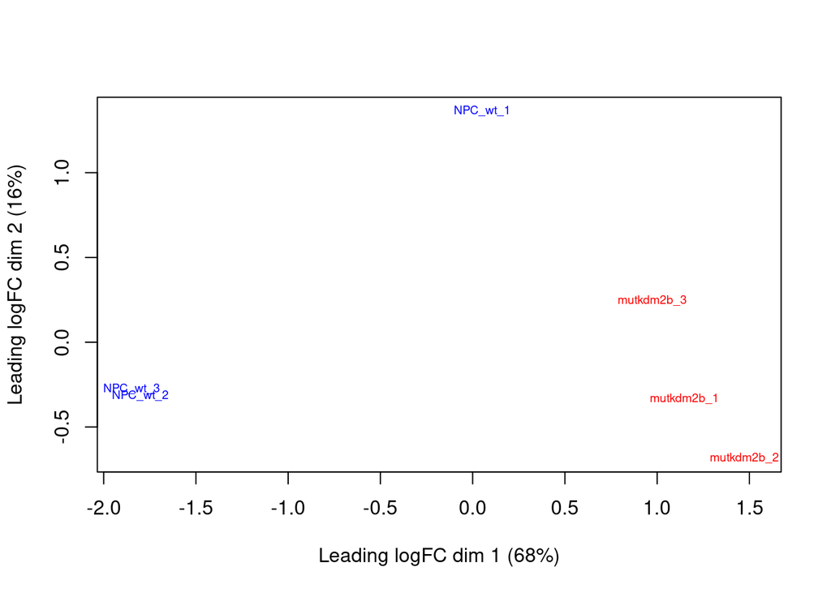

```r
# multidimensional scaling plot of samples
plotMDS(DG, cex = 0.6, col = c(rep("blue", 3), rep("red", 3)))
```

According to the plot, the greatest sources of variation in the data are the ones investigated: there is a clear distinction between the wtand the mutated group that suggests that the gene expression profiles are different between these two groups.

Now estimate the tagwise dispersion, that is the gene-specific PHI, corresponding to the biological coefficient of variation, for the NB distribution

```r
# estimate negative binomial dispersions, it estimates PHI of the Negative Binomial
DG <- estimateDisp(DG)
```

```
## Using classic mode.
```

```r
head(DG$tagwise.dispersion)
```

```
## [1] 0.03692760 0.02413925 0.03245925 0.03384745 0.03659830 0.02301435
```

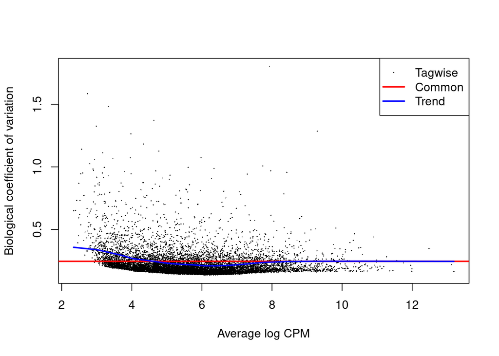

```r
plotBCV(DG)
```

Test for differentially expressed genes (DEGs) with `exactTest`. With this method, a p-value is assigned to each gene, estimating the likelihood of differential expression.

```r
# perform test for differential expression between the two conditions
diff_expr_test <- exactTest(DG, c("NPC_wt", "mut_kdm2b"))
```

Use the `topTags` function is employed to identify genes with significant p-values: the p-value threshold is an indicator of the False Discovery Rate (FDR) which corrects for multiple hypothesis testing.

```r
# select genes with significant diff. expression (FDR <= 0.01)
diff_expr_test_sign <- topTags(diff_expr_test, n = nrow(diff_expr_test), p.value = 0.01)
```

Check the differential expressed genes (DEGs).

```r
# check the differential expressed genes (DEGs)
head(diff_expr_test_sign$table)
```

```
##             logFC   logCPM       PValue          FDR
## Pcdhga7  6.506085 4.852131 1.245647e-92 1.266075e-88
## Hoxa5   -6.367682 3.786374 1.017701e-45 5.171955e-42
## Elfn1    2.879378 5.259442 2.348367e-29 7.956267e-26
## Hoxa3   -6.718743 2.878185 9.354731e-28 2.377037e-24
## Pcdhgc4  3.660160 4.578150 1.309406e-27 2.661760e-24
## Pcdh17   4.048832 4.268646 3.854174e-27 6.528971e-24
```

```r
tail(diff_expr_test_sign$table)
```

```
##             logFC   logCPM       PValue         FDR
## Tst     1.3849669 4.113944 0.0006384492 0.009907172
## Atp1a2  4.3070503 6.277331 0.0006414488 0.009920743
## Mpg    -1.7753626 2.981261 0.0006415781 0.009920743
## Cdh6   -1.2258775 6.222830 0.0006422520 0.009920743
## Mapre3  0.8690868 4.629930 0.0006487773 0.009997691
## Wnt7b   1.5616994 7.292826 0.0006492007 0.009997691
```

Now check the number of up and down regulated genes

```r
# up-regulated genes (more expressed in infected)
sum(diff_expr_test_sign$table$logFC > 0)
```

```
## [1] 464
```

```r
# down-regulated genes (less expressed in infected)
sum(diff_expr_test_sign$table$logFC < 0)
```

```
## [1] 196
```

According to our FDR threshold, we have 464 upregulated genes, that is significantly more expressed in mutated samples and 196 downregulated genes, that is significantly less expressed in mutated samples.

```r
# divide for up and down regulated genea
up_regulated_genes <- row.names(diff_expr_test_sign$table)[diff_expr_test_sign$table$logFC > 0]
down_regulated_genes <- row.names(diff_expr_test_sign$table)[diff_expr_test_sign$table$logFC < 0]
```

Now check the CPM distribution across all samples for the upregulated genes with two boxplots (one for the up-regulated and one for the down-regulated).

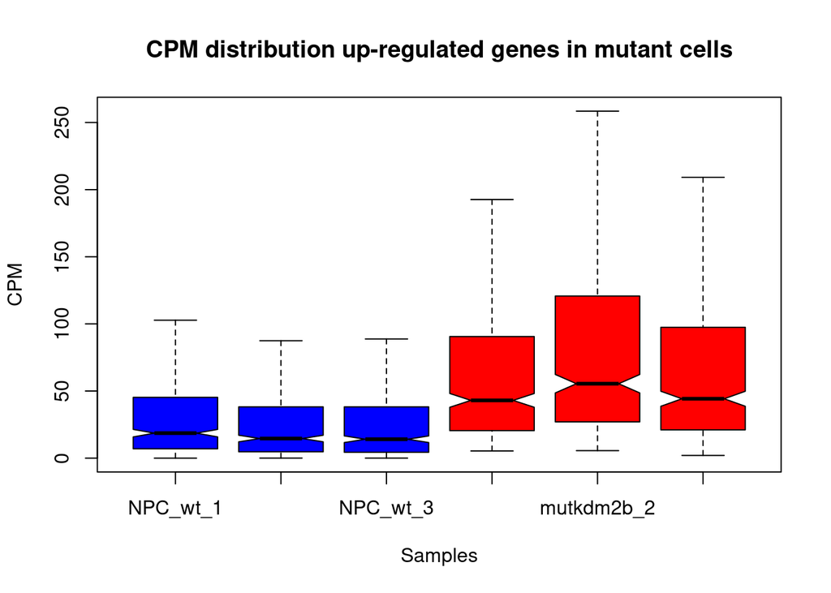

```r
# boxplot up
boxplot(cpm(DG) [up_regulated_genes,], notch = T, outline = F, col = c(rep("blue", 3), rep("red", 3)),
        ylab = "CPM", xlab ="Samples", main = "CPM distribution up-regulated genes in mutant cells")
```

In this picture is shown a boxplot for overexpressed genes: in particular it shows the distribution of CPM (Counts Per Million) values for genes that are identified as up-regulated in cells with kdm2b mutation (red) compared to the wt ones (blue). You can immediately see an higher expression of the genes in mutated cells (red) that can suggest that these genes are involved somehow and could have a role in some pathways

[figure not shown]

```r
# boxplot down
boxplot(cpm(DG) [down_regulated_genes,], notch = T, outline = F, col = c(rep("blue", 3), rep("red", 3)),
        ylab = "CPM", xlab ="Samples", main = "CPM distribution up-regulated genes in mutant cells")
```

Similarly, this boxplot shows CPM values for down-regulated genes in cells with kdm2b mutation. Also in this case, the mutated cells (red) are compared to the mock ones (blue). Here you can see a reduction in the activity of these genes as a result of the mutation, that can means that some processes in which these genes have a role could be suppressed as a consequence of the mutation.

**Visualize the results with a scatterplot**

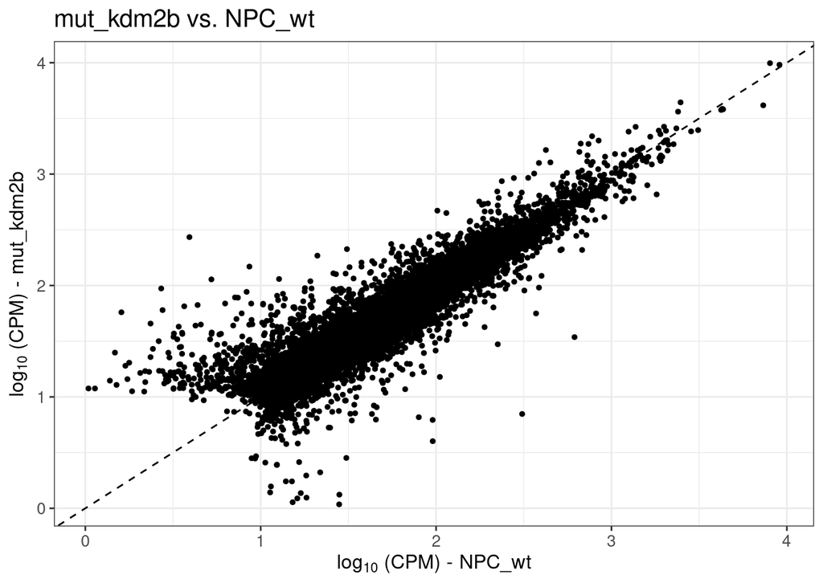

```r
# scatterplot
vsScatterPlot(x = "NPC_wt", y = "mut_kdm2b", data = DG, type = "edger")
```

In this scatterplot, each gene is represented by a dot and the genes that deviate from the diagonal line represent genes that show significant differences in expression between the two groups.

**Visualize the results with a volcano plot**

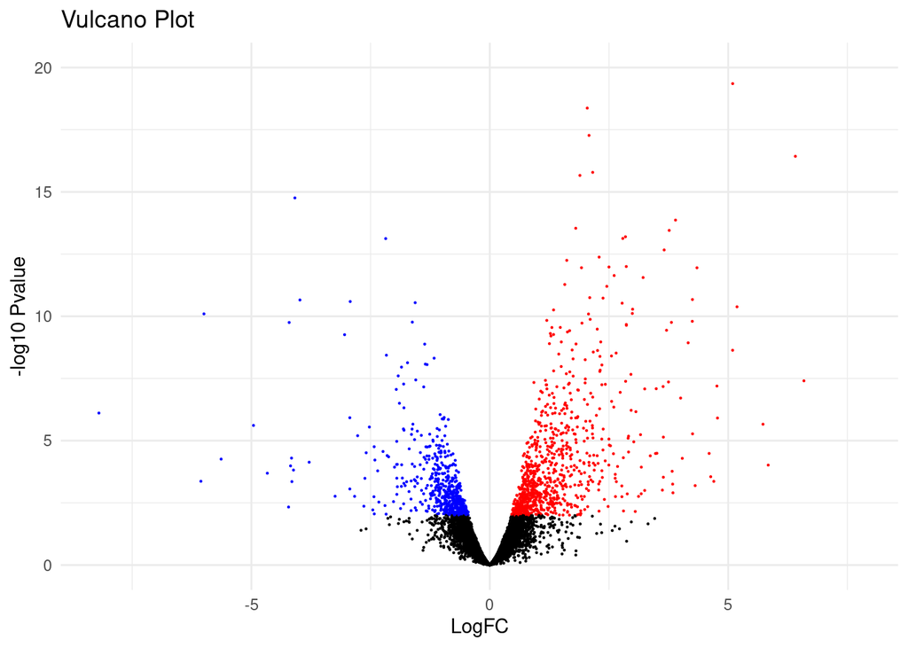

```r
# vulcano plot
# set colors
colors <- ifelse(diff_expr_test$table$PValue <= 0.01, ifelse(diff_expr_test$table$logFC > 0, "red", "blue"),
                 "black")
# plot
vulcano_plot <- ggplot(diff_expr_test$table, aes(x = logFC, y = -log10(PValue))) +
  geom_point(color = colors, size = 0.1) +
  labs(x = "LogFC", y = "-log10 Pvalue", title = "Vulcano Plot") +
  ylim(0, 20) +
  theme_minimal()
print(vulcano_plot)
```

In this vulcano plot we have the logFC on the X-axis against the - log10(PValue) on the Y-axis and the red dots represent the significant up-regulated genes, blue means significant down-regulated genes, and black means non-significant. The points furthest from the origin are the genes with the greatest (statistically meaningful) differences in expression.

**Visualize the results with a MA plot**

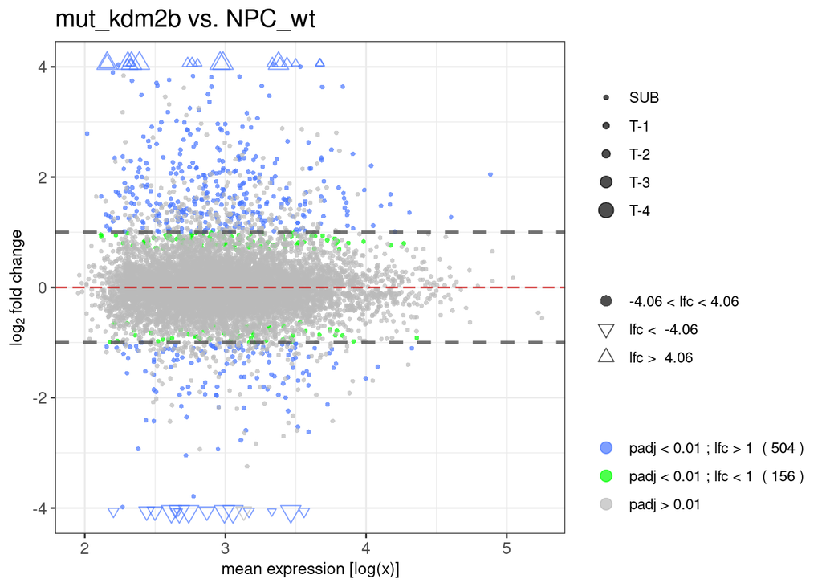

```r
# MA plot
vsMAPlot(x = "NPC_wt", y = "mut_kdm2b", data = DG, type = "edger", padj = 0.01)
```

This MA plot shows the mean expression against the logFC. Based on the colors of the dots you can see different combinations (for example: blue dots means adjusted p-value of <0.01 and LFC of > 1 etc.)

# **ChIP-Seq analysis**

ChIP-Seq analysis in this study is crucial to identify the specific genomic regions where the KDM2B protein binds, elucidating the molecular mechanisms underlying its role in regulating gene expression

Load the data

```bash
cd ../ChIP-Seq
head load_data_chip.sh
```

```
## fasterq-dump SRR17223711
## fasterq-dump SRR17223712
## fasterq-dump SRR17223713
## fasterq-dump SRR17223714
```

# FASTQ quality score

Use `fastqc` for overall reads quality check: `fastqc *fastq`

Use `multiqc .` in the project_track1/ChIP-Seq dir to summarize all the fastqc results of chipseq data in a single html report

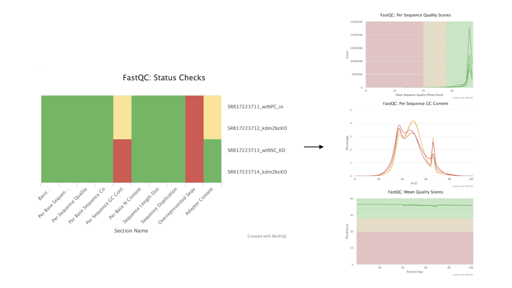

# Mapping

Download the mm9 genome

```bash
cd ../ChIP-Seq
head ref.sh
```

```
## Index
## wget https://hgdownload.soe.ucsc.edu/goldenPath/mm9/bigZips/mm9.fa.gz
## gunzip mm9.fa.gz
```

check the chromosomes

```bash
cd ../ChIP-Seq/Index/mm9
grep ">" mm9.fa |more
```

```
## >chr1
## >chr2
## >chr3
## >chr4
## >chr5
## >chr6
## >chr7
## >chr8
## >chr9
## >chr10
## >chr11
## >chr12
## >chr13
## >chr14
## >chr15
## >chr16
## >chr17
## >chr18
## >chr19
## >chrX
## >chrY
## >chrM
## >chr13_random
## >chr16_random
## >chr17_random
## >chr1_random
## >chr3_random
## >chr4_random
## >chr5_random
## >chr7_random
## >chr8_random
## >chr9_random
## >chrUn_random
## >chrX_random
## >chrY_random
```

Split the chromosomes in different fasta files

```bash
cd ../ChIP-Seq/Index/mm9
head remove_anom_chrom.sh
```

```
## cat mm9.fa | awk '{
##         if (substr($0, 1, 1)==">") {filename=(substr($0,2) ".fa")}
##         print $0 >> filename
##         close(filename)
## }'
```

Remove the anomalous chromosomes (random and M) and concatenate the remaining ones:

```bash
cd ../ChIP-Seq/Index/mm9
head remove_anom_chrom2.sh
```

```
## rm *_random.fa
## rm *M.fa
## cat chr*.fa
```

Run the bowtie2-build program to build the Bowtie index of the mus musculus genome. NB: use bowtie2 since the reads are longer: `nohup bowtie2-build --threads 4 mm9/mm9.fa mm9 &`

Prepare a map.script to map all the samples with `bowtie2`. It will generate the bam files

```bash
cd ../ChIP-Seq
head map.sh
```

```
## bowtie2 -k10 --very-sensitive-local -N 1 -L 20 -i S,1,0.50 -D 20 -R 3 -p 6 -x /home/MBB24_adig/project_track1/ChIP-Seq/Index/mm9 -U /home/MBB24_adig/project_track1/ChIP-Seq/SRR17223711_wtNPC_input.fastq | samtools view -b > SRR17223711_wtNPC_input.bam
##
## bowtie2 -k10 --very-sensitive-local -N 1 -L 20 -i S,1,0.50 -D 20 -R 3 -p 6 -x /home/MBB24_adig/project_track1/ChIP-Seq/Index/mm9 -U /home/MBB24_adig/project_track1/ChIP-Seq/SRR17223712_kdm2bcKONPC_input.fastq | samtools view -b > SRR17223712_kdm2bcKONPC_input.bam
##
## bowtie2 -k10 --very-sensitive-local -N 1 -L 20 -i S,1,0.50 -D 20 -R 3 -p 6 -x /home/MBB24_adig/project_track1/ChIP-Seq/Index/mm9 -U /home/MBB24_adig/project_track1/ChIP-Seq/SRR17223713_wtNSC_KDM2B.fastq | samtools view -b > SRR17223713_wtNSC_KDM2B.bam
##
## bowtie2 -k10 --very-sensitive-local -N 1 -L 20 -i S,1,0.50 -D 20 -R 3 -p 6 -x /home/MBB24_adig/project_track1/ChIP-Seq/Index/mm9 -U /home/MBB24_adig/project_track1/ChIP-Seq/SRR17223714_kdm2bcKONPC_KDM2B.fastq | samtools view -b > SRR17223714_kdm2bcKONPC_KDM2B.bam
```

With `samtools` stats followed by `plot-bamstats` we can collect some post-mapping quality info

```bash
cd ../ChIP-Seq
head stats.sh
```

```
## samtools stats SRR17223711_wtNPC_input.bam > SRR17223711_wtNPC_input.bam.stats
## samtools stats SRR17223712_kdm2bcKONPC_input.bam > SRR17223712_kdm2bcKONPC_input.bam.stats
## samtools stats SRR17223713_wtNSC_KDM2B.bam > SRR17223713_wtNSC_KDM2B.bam.stats
## samtools stats SRR17223714_kdm2bcKONPC_KDM2B.bam > SRR17223714_kdm2bcKONPC_KDM2B.bam.stats
```

```
## plot-bamstats -p SRR17223711_wtNPC_input_stats/ SRR17223711_wtNPC_input.bam.stats
## plot-bamstats -p SRR17223712_kdm2bcKONPC_input_stats/ SRR17223712_kdm2bcKONPC_input.bam.stats
## plot-bamstats -p SRR17223713_wtNSC_KDM2B_stats/ SRR17223713_wtNSC_KDM2B.bam.stats
## plot-bamstats -p SRR17223714_kdm2bcKONPC_KDM2B_stats/ SRR17223714_kdm2bcKONPC_KDM2B.bam.stats
```

[figure not shown]

```bash
cd ../ChIP-Seq
head plot_stats.sh
```

# Peak Calling

With the peak calling we want to identify regions of the genome (peaks) where KDM2B binds to DNA. These peaks represent areas of DNA enrichment that have been immunoprecipitated and sequenced.

For each IP/control pair, we use `macs2` call peak on the BAM files (use `-g mm` for mus musculus genome)

```bash
cd ../ChIP-Seq
head callpeak.sh
```

```
## macs2 callpeak -t SRR17223713_wtNSC_KDM2B.bam -c SRR17223711_wtNPC_input.bam -g mm -n wtNSC_KDM2B_vs_wtNPC_input --outdir wtNSC_KDM2B_peaks
##
## macs2 callpeak -t SRR17223714_kdm2bcKONPC_KDM2B.bam -c SRR17223712_kdm2bcKONPC_input.bam -g mm -n kdm2bcKONPC_KDM2B_vs_kdm2bcKONPC_input --outdir kdm2bcKONPC_KDM2B_peaks
```

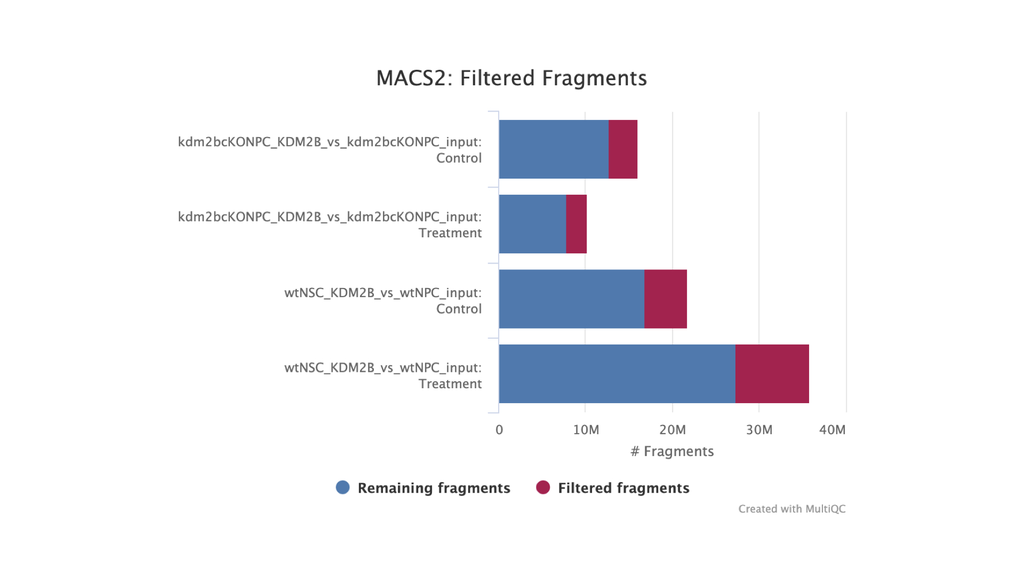

To generate plots of the peaks:

`R CMD BATCH kdm2bcKONPC_KDM2B_vs_kdm2bcKONPC_input_model.r`

Count the peaks in the two replicates

```bash
cd ../ChIP-Seq/wtNSC_KDM2B_peaks
wc -l wtNSC_KDM2B_vs_wtNPC_input_peaks.narrowPeak
cd ../kdm2bcKONPC_KDM2B_peaks
wc -l kdm2bcKONPC_KDM2B_vs_kdm2bcKONPC_input_peaks.narrowPeak
```

```
## 3517 wtNSC_KDM2B_vs_wtNPC_input_peaks.narrowPeak
## 376 kdm2bcKONPC_KDM2B_vs_kdm2bcKONPC_input_peaks.narrowPeak
```

It is not uncommon for one replicate to have fewer peaks than others due to insufficient coverage or other reasons

Check how many of them overlap

```bash
cd ../ChIP-Seq
bedtools intersect -u -b wtNSC_KDM2B_peaks/wtNSC_KDM2B_vs_wtNPC_input_peaks.narrowPeak -a kdm2bcKONPC_KDM2B_peaks/kdm2bcKONPC_KDM2B_vs_kdm2bcKONPC_input_peaks.narrowPeak |wc -l
```

```
## 96
```

Now we have to keep only the peaks that overlap and merge them. Once we know that the two replicates are consistent, we can use the Irreproducible Discovery Rate (IDR) method.

Assigning an IDR (Irreproducible Discovery Rate) value to each peak allows us to assess how reproducible a peak is between replications. A lower IDR value indicates greater reproducibility, while a higher value suggests greater variability among replications.

```bash
cd ../ChIP-Seq
head idr.sh
```

```
## idr -s wtNSC_KDM2B_peaks/wtNSC_KDM2B_vs_wtNPC_input_peaks.narrowPeak kdm2bcKONPC_KDM2B_peaks/kdm2bcKONPC_KDM2B_vs_kdm2bcKONPC_input_peaks.narrowPeak -o kdm2b_idr.narrowPeak --idr-threshold 0.05 --plot
```

# Coverage of peaks

We want to explore the coverage of reads from our ChIP-Seq and control samples on the peaks we identified

```r
# libraries
library(GenomicRanges)
library(rtracklayer)
library(GenomicAlignments)
```

import bam files

```r
# import bam files
wt_NPC_input1_bam <- readGAlignments("~/project_track1/ChIP-Seq/SRR17223711_wtNPC_input.bam")
KDM2B_rep1_bam <- readGAlignments("~/project_track1/ChIP-Seq/SRR17223713_wtNSC_KDM2B.bam")

KO_KDM2B_input2_bam<- readGAlignments("~/project_track1/ChIP-Seq/SRR17223712_kdm2bcKONPC_input.bam")
KO_KDM2B_KDM2B_rep2_bam <- readGAlignments("~/project_track1/ChIP-Seq/SRR17223714_kdm2bcKONPC_KDM2B.bam")
```

```r
# check the length
print(paste("Length of wt_NPC_input1_bam:", length(wt_NPC_input1_bam)))
```

```
## [1] "Length of wt_NPC_input1_bam: 107887083"
```

```r
print(paste("Length of KDM2B_rep1_bam:", length(KDM2B_rep1_bam)))
```

```
## [1] "Length of KDM2B_rep1_bam: 166919583"
```

```r
print(paste("Length of KO_KDM2B_input2_bam:", length(KO_KDM2B_input2_bam)))
```

```
## [1] "Length of KO_KDM2B_input2_bam: 78391041"
```

```r
print(paste("Length of KO_KDM2B_KDM2B_rep2_bam:", length(KO_KDM2B_KDM2B_rep2_bam)))
```

```
## [1] "Length of KO_KDM2B_KDM2B_rep2_bam: 51847224"
```

Compute library size normalisation factors. We use one sample (KDM2B_rep1_bam) as the reference and compute the normalisation factors for the other three samples.

```r
# compute library normalization factors
NF <- list()

NF$rep1_input1 <- length(KDM2B_rep1_bam) / length(wt_NPC_input1_bam)
NF$rep1_rep2 <- length(KDM2B_rep1_bam) / length(KO_KDM2B_KDM2B_rep2_bam)
NF$rep1_input2 <- length(KDM2B_rep1_bam) / length(KO_KDM2B_input2_bam)

NF
```

```
## $rep1_input1
## [1] 1.547169
##
## $rep1_rep2
## [1] 3.219451
##
## $rep1_input2
## [1] 2.12932
```

Import the IDR peaks with the `import` funtion. The peaks have variable lengths, but we need peaks of the same length to compute the average position-by- position coverage. We can use the “summits” column of the narrowPeak file as the “anchor point” of each peak.

```r
# import idr peaks
idr_peaks <- import("~/project_track1/ChIP-Seq/kdm2b_idr.narrowPeak", format = "bed", colnames = c("chrom", "start", "end"))
summary(width(idr_peaks))
```

```
##    Min. 1st Qu.  Median    Mean 3rd Qu.    Max.
##   193.0   576.2   749.5  1176.2   935.0 16299.0
```

```r
# get summit offset columns in GRanges object
mcols(idr_peaks)$summit <- read.table("~/project_track1/ChIP-Seq/kdm2b_idr.narrowPeak")[,10]
mcols(idr_peaks)$w <- width(idr_peaks)
idr_peaks
```

```
## GRanges object with 44 ranges and 2 metadata columns:
##        seqnames              ranges strand |    summit         w
##           <Rle>           <IRanges>  <Rle> | <integer> <integer>
##    [1]     chrM             1-16299      * |     10794     16299
##    [2]     chr1 168308969-168309999      * |       352      1031
##    [3]     chr4 154597109-154597780      * |       290       672
##    [4]    chr14   55304943-55305965      * |       723      1023
##    [5]    chr11 104411379-104412164      * |       530       786
##    ...      ...                 ...    ... .       ...       ...
##   [40]    chr11   49944720-49945074      * |       136       355
##   [41]     chr2   35516581-35516840      * |       120       260
##   [42]     chr3 119485775-119486422      * |       487       648
##   [43]     chr8 131209435-131209908      * |       284       474
##   [44]    chr15   27955242-27956051      * |       320       810
##   -------
##   seqinfo: 15 sequences from an unspecified genome; no seqlengths
```

here we are reading the file `kdm2b_idr.narrowPeak` as a table and we aree extracting the 10th column, which contains the summit positions (the points of highest coverage within the peaks). These positions are then added as a metadata column named “summit” to the `GRanges` object (`idr_peaks`).

With the shift and flank functions, we standardise our peaks to have a width of 2000bps centred around the summits identified bymacs (thepeakcaller).

```r
# create a new peaks object with standard widths (anchored on summits)
idr_peaks_summit <- flank(shift(idr_peaks, shift = idr_peaks$summit), width = 1000, both = TRUE)
idr_peaks_summit$summits <- NULL
idr_peaks_summit$w <- width(idr_peaks_summit)
idr_peaks_summit
```

```
## GRanges object with 44 ranges and 2 metadata columns:
##        seqnames              ranges strand |    summit         w
##           <Rle>           <IRanges>  <Rle> | <integer> <integer>
##    [1]     chrM          9795-11794      * |     10794      2000
##    [2]     chr1 168308321-168310320      * |       352      2000
##    [3]     chr4 154596399-154598398      * |       290      2000
##    [4]    chr14   55304666-55306665      * |       723      2000
##    [5]    chr11 104410909-104412908      * |       530      2000
##    ...      ...                 ...    ... .       ...       ...
##   [40]    chr11   49943856-49945855      * |       136      2000
##   [41]     chr2   35515701-35517700      * |       120      2000
##   [42]     chr3 119485262-119487261      * |       487      2000
##   [43]     chr8 131208719-131210718      * |       284      2000
##   [44]    chr15   27954562-27956561      * |       320      2000
##   -------
##   seqinfo: 15 sequences from an unspecified genome; no seqlengths
```

We need to have the same `seqlevels` for the peak files and the alignment: so we need to remove all the unnecessary alignments on the non-shared chromosomes: With the `pruning mode = "coarse"` argument of `seqlevels`, we remove them from the BAM objects.

```r
# in order to have the same seqlevels (same chromosomes) we remove the unwanted and non-shared chroms
seqlevels(wt_NPC_input1_bam, pruning.mode = "coarse") <- seqlevels(KDM2B_rep1_bam,pruning.mode = "coarse") <-
  seqlevels(KO_KDM2B_input2_bam, pruning.mode = "coarse") <- seqlevels(KO_KDM2B_KDM2B_rep2_bam, pruning.mode = "coarse") <-
  seqlevels(idr_peaks_summit)

# now we have the same seqlevels for all the objects
seqlevels(idr_peaks_summit)
```

```
##  [1] "chrM"  "chr1"  "chr4"  "chr14" "chr11" "chrX"  "chr7"  "chr2"  "chr8"
## [10] "chr10" "chr16" "chr19" "chr3"  "chr6"  "chr15"
```

```r
seqlevels(wt_NPC_input1_bam)
```

```
##  [1] "chrM"  "chr1"  "chr4"  "chr14" "chr11" "chrX"  "chr7"  "chr2"  "chr8"
## [10] "chr10" "chr16" "chr19" "chr3"  "chr6"  "chr15"
```

```r
seqlevels(KDM2B_rep1_bam)
```

```
##  [1] "chrM"  "chr1"  "chr4"  "chr14" "chr11" "chrX"  "chr7"  "chr2"  "chr8"
## [10] "chr10" "chr16" "chr19" "chr3"  "chr6"  "chr15"
```

```r
seqlevels(KO_KDM2B_input2_bam)
```

```
##  [1] "chrM"  "chr1"  "chr4"  "chr14" "chr11" "chrX"  "chr7"  "chr2"  "chr8"
## [10] "chr10" "chr16" "chr19" "chr3"  "chr6"  "chr15"
```

```r
seqlevels(KO_KDM2B_KDM2B_rep2_bam)
```

```
##  [1] "chrM"  "chr1"  "chr4"  "chr14" "chr11" "chrX"  "chr7"  "chr2"  "chr8"
## [10] "chr10" "chr16" "chr19" "chr3"  "chr6"  "chr15"
```

Now we can compute the coverage (how many reads align in each position) with the coverage function.

```r
# compute coverage from the BAM files
cov_wt_NPC_input1 <- coverage(wt_NPC_input1_bam)
cov_KDM2B_rep1 <- coverage(KDM2B_rep1_bam)
cov_KO_KDM2B_input2 <- coverage(KO_KDM2B_input2_bam)
cov_KO_KDM2B_KDM2B_rep2 <- coverage(KO_KDM2B_KDM2B_rep2_bam)
```

Use the `Views` function to get the coverages around the peak summits

```r
# get Views on peak regions
peaks_cov_wt_NPC_input1 <- Views(cov_wt_NPC_input1, idr_peaks_summit)
peaks_cov_KDM2B_rep1 <- Views(cov_KDM2B_rep1, idr_peaks_summit)
peaks_cov_KO_KDM2B_input2 <- Views(cov_KO_KDM2B_input2, idr_peaks_summit)
peaks_cov_KO_KDM2B_KDM2B_rep2 <- Views(cov_KO_KDM2B_KDM2B_rep2, idr_peaks_summit)
```

Use `colMeans` to calculate the average coverage at each position of the normalized peaks by length on the Views objects after converting to matrix

During the conversion, the normalization factors calculated earlier are also used to normalize the coverage of each sample.

```r
# convert Views to matrix so we can use colmeans function and normalise for library size
peaks_allcov_input1 <- as.matrix(peaks_cov_wt_NPC_input1) * NF$rep1_input1
peaks_allcov_rep1 <- as.matrix(peaks_cov_KDM2B_rep1)

peaks_allcov_input2 <- as.matrix(peaks_cov_KO_KDM2B_input2) * NF$rep1_input2
peaks_allcov_rep2 <- as.matrix(peaks_cov_KO_KDM2B_KDM2B_rep2) * NF$rep1_rep2

peaks_meancov_input1 <- colMeans(peaks_allcov_input1)
peaks_meancov_rep1 <- colMeans(peaks_allcov_rep1)

peaks_meancov_input2 <- colMeans(peaks_allcov_input2)
peaks_meancov_rep2 <- colMeans(peaks_allcov_rep2)
```

Plot the mean coverage vectors

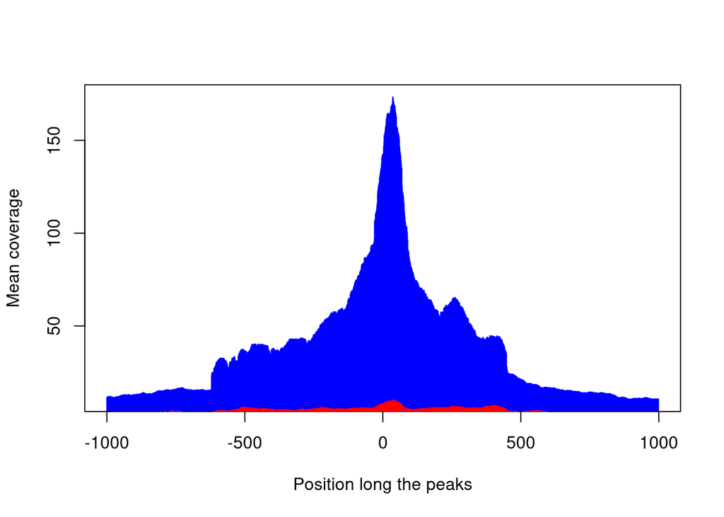

```r
# plot coverages on peaks
plot(peaks_meancov_rep1, type = "h", x = -1000:999, col = "blue", xlab = "Position long the peaks", ylab = "Mean coverage")
points(peaks_meancov_input1, type = "h", x = -1000:999, col = "red")
```

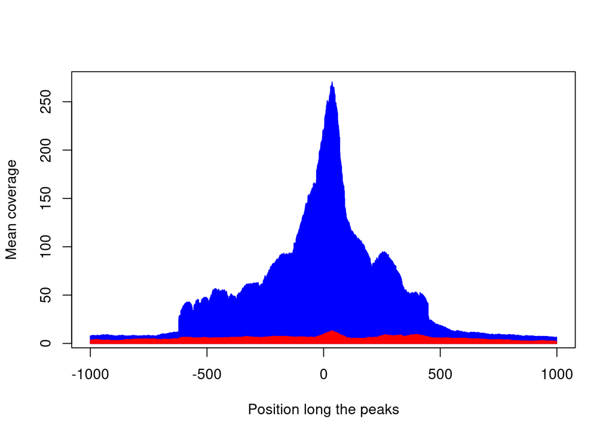

```r
plot(peaks_meancov_rep2, type = "h", x = -1000:999, col = "blue", xlab = "Position long the peaks", ylab = "Mean coverage")
points(peaks_meancov_input2, type = "h", x = -1000:999, col = "red")
```

Draw boxplots of the mean coverage

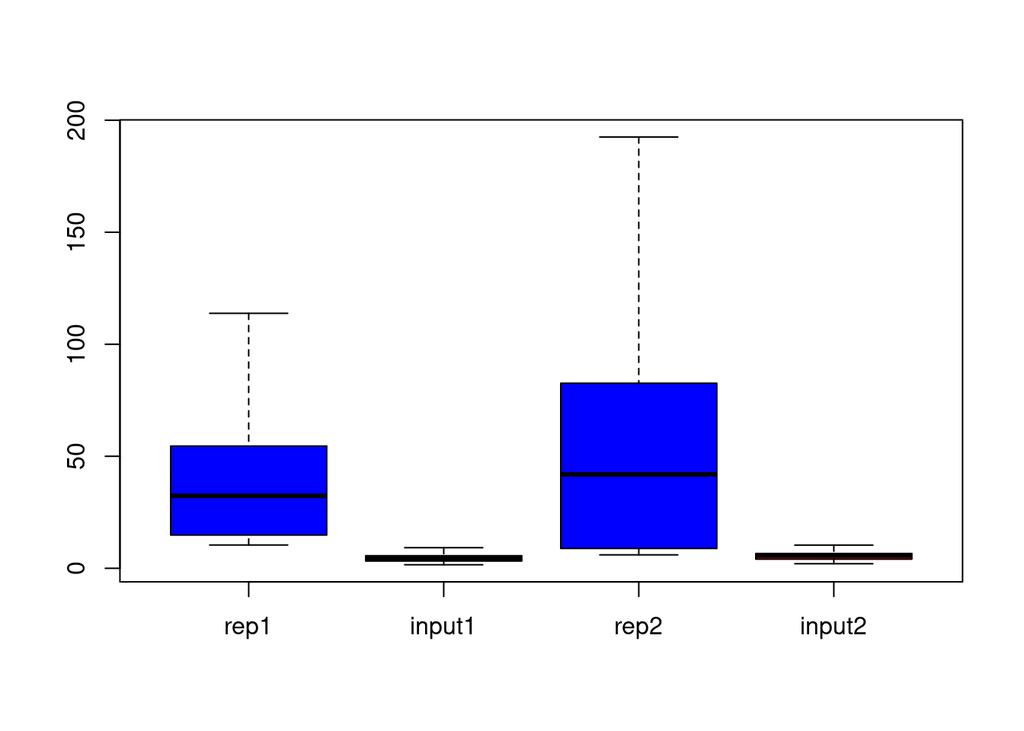

```r
# boxplots
boxplot(peaks_meancov_rep1, peaks_meancov_input1, peaks_meancov_rep2, peaks_meancov_input2,
        col = rep(c("blue", "red"), 2), outline = FALSE, names = c("rep1", "input1", "rep2", "input2"))
```

Check what happens outside of peaks:

```r
# check the coverage outside the peak regions
shifted_idr_peaks_summits <- shift(idr_peaks_summit, 4000) # shift every peak of 1k positions

# get Views on shifted peak regions
s_peaks_cov_wt_NPC_input1 <- Views(cov_wt_NPC_input1, shifted_idr_peaks_summits)
s_peaks_cov_KDM2B_rep1 <- Views(cov_KDM2B_rep1, shifted_idr_peaks_summits)
s_peaks_cov_KO_KDM2B_input2 <- Views(cov_KO_KDM2B_input2, shifted_idr_peaks_summits)
s_peaks_cov_KO_KDM2B_KDM2B_rep2 <- Views(cov_KO_KDM2B_KDM2B_rep2, shifted_idr_peaks_summits)
```

```r
# convert Views to matrix so we can use colmeans function and normalise for library size
s_peaks_allcov_input1 <- as.matrix(s_peaks_cov_wt_NPC_input1) * NF$rep1_input1
s_peaks_allcov_rep1 <- as.matrix(s_peaks_cov_KDM2B_rep1)

s_peaks_allcov_input2 <- as.matrix(s_peaks_cov_KO_KDM2B_input2) * NF$rep1_input2
s_peaks_allcov_rep2 <- as.matrix(s_peaks_cov_KO_KDM2B_KDM2B_rep2) * NF$rep1_rep2

s_peaks_meancov_input1 <- colMeans(s_peaks_allcov_input1)
s_peaks_meancov_rep1 <- colMeans(s_peaks_allcov_rep1)

s_peaks_meancov_input2 <- colMeans(s_peaks_allcov_input2)
s_peaks_meancov_rep2 <- colMeans(s_peaks_allcov_rep2)
```

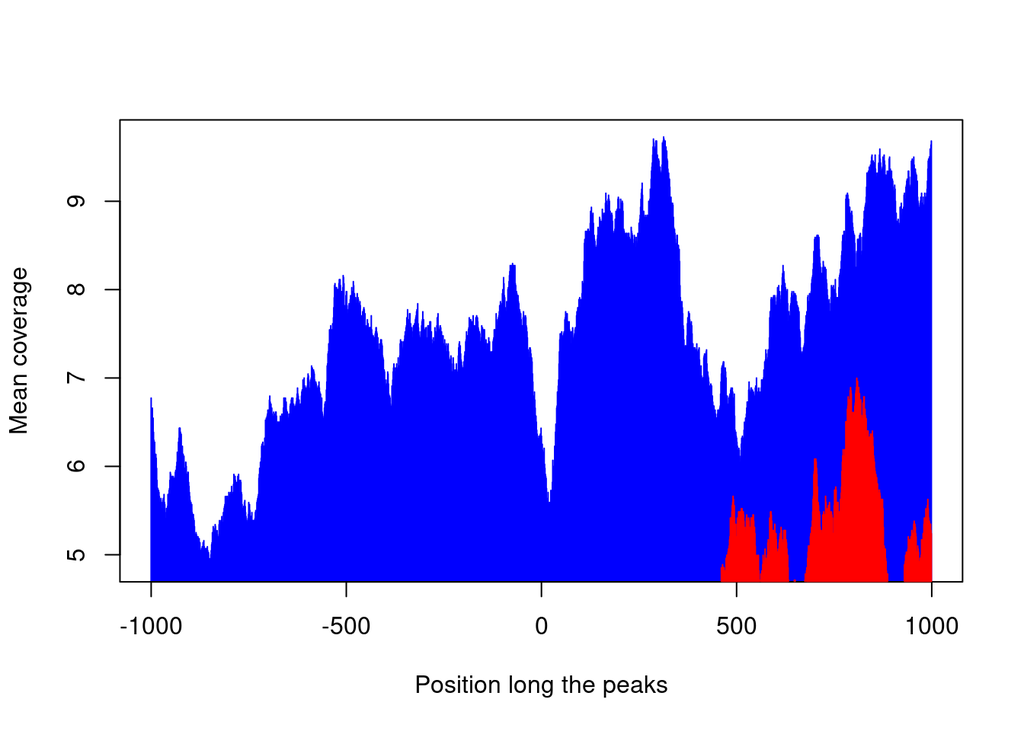

```r
# look at the coverage
# plot coverages
plot(s_peaks_meancov_rep1, type = "h", x = -1000:999, col = "blue", xlab = "Position long the peaks", ylab = "Mean coverage")
points(s_peaks_meancov_input1, type = "h", x = -1000:999, col = "red")
```

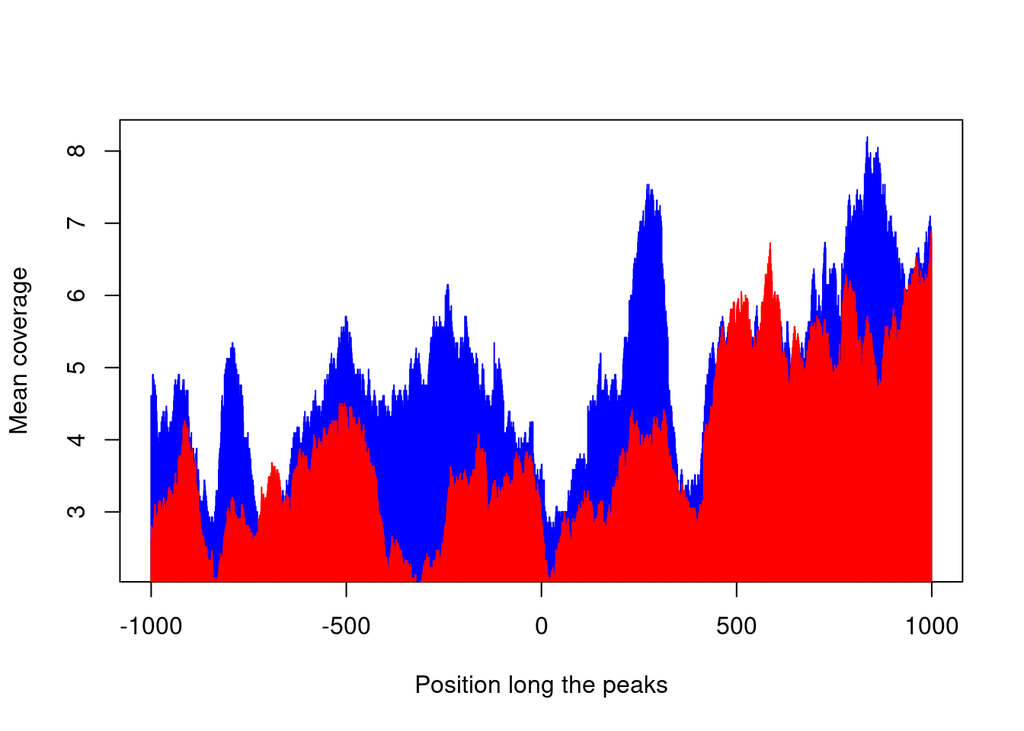

```r
plot(s_peaks_meancov_rep2, type = "h", x = -1000:999, col = "blue", xlab = "Position long the peaks", ylab = "Mean coverage")
points(s_peaks_meancov_input2, type = "h", x = -1000:999, col = "red")
```

Boxplots:

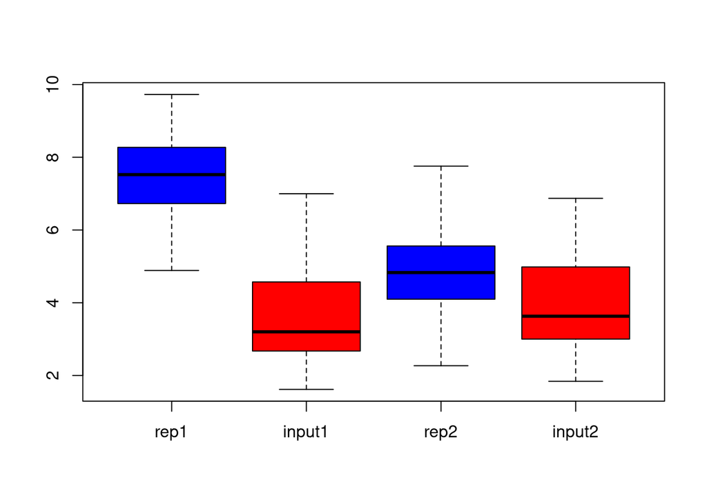

```r
# boxplots
boxplot(s_peaks_meancov_rep1, s_peaks_meancov_input1, s_peaks_meancov_rep2, s_peaks_meancov_input2,
        col = rep(c("blue", "red"), 2), outline = FALSE, names = c("rep1", "input1", "rep2", "input2"))
```